# Science One CS – More Loops and Plotting

# Plotting

It would be handy to make a plot of $y$ vs $x$ to visualize the function $y = x^2$.

We can use a package in Python called `matplotlib.pyplot` to make graphs, but it requires an array of data for each the $y$-axis and the $x$-axis to do so. Lucky for us, we just created those arrays.

### Exercise 3

**Try it:**

Run the cell below to import `matplotlib.pyplot` under the new convenient "nickname" `plt`

```python
import matplotlib.pyplot as plt
```

The library `matplotlib.pyplot` contains very simple functions to plot and includes handy features to label your axes. The two basic functions are `plt.plot` and `plt.show`.

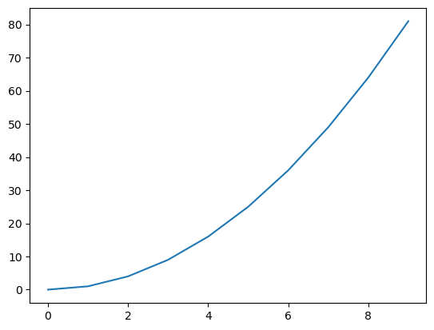

```python
plt.plot(x, y)
plt.show()
```

**Try it:**

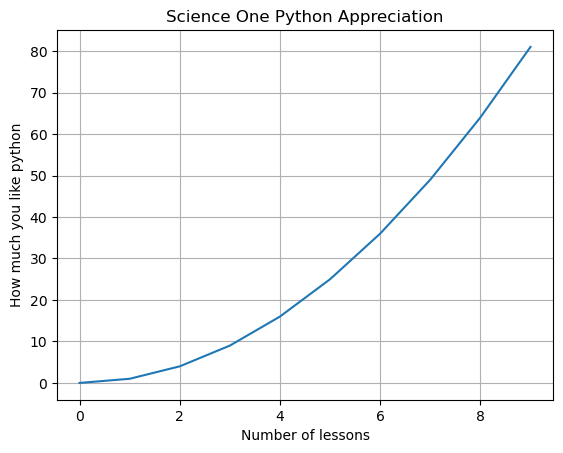

```python
plt.title('Science One Python Appreciation')
plt.plot(x, y)
plt.ylabel('How much you like python')
plt.xlabel('Number of lessons')
plt.grid(True)
plt.show()
```

Matplotlib has SO MANY features. We'll only see a few today. You can adjust axes limits and the ticks shown.

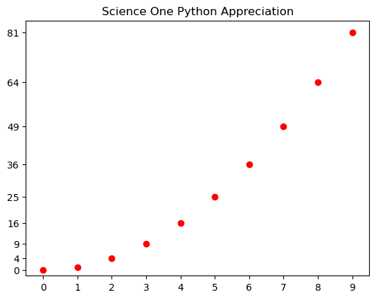

```python
plt.title('Science One Python Appreciation')
plt.plot(x, y, 'ro') #The r specifies plotting in red and the o tells Python to plot dots
plt.xlim([-0.5, 9.5])
plt.ylim([-2, 85])
plt.yticks(ticks=[0, 4, 9, 16, 25, 36, 49, 64, 81])
plt.xticks(ticks=x)
plt.show()
```

# Bonus Challanges

### Exercise 4

Make an array of the first 10 powers of 2 using a while loop. The array should look something like `np.array([2 4 8 ... 1024])`.

Your code should look something like this:

```
# initialize an array
while # some condition here :
    # some more code in here
# print the array
```

(This is almost idential to the Exercise that was in "L02 Booleans and Loops" Exercise 5)

```python
# Solution 1
a = np.array([])
i = 1
while len(a) < 10:
    i = i*2 # notice we update the index first since we want to start at 2, not 1
    a = np.append(a, i)
print(a)
```

```
[   2.    4.    8.   16.   32.   64.  128.  256.  512. 1024.]
```

```python
# Solution 2
a = np.zeros(10)
i = 0
while i < 10:
    a[i] = 2**(i+1) # need to shift by one since we want the first term to be 2=2^1, not 1=2^0
    i = i + 1
print(a)
```

```
[   2.    4.    8.   16.   32.   64.  128.  256.  512. 1024.]
```

Can you use `np.linspace` to make the same array?

```python
i = np.linspace(1, 10, 10)
a = 2**i
print(a)
```

```
[   2.    4.    8.   16.   32.   64.  128.  256.  512. 1024.]
```

### Exercise 5

Use the array `np.array([2 4 8 ...])` you made in the previous exercise to calculate the following sum we saw in last lesson "L02 Booleans and Loops" Exercise 3: $$\frac{1}{2}+\frac{1}{4}+\frac{1}{8}+...+\frac{1}{1024}.$$

You should be able to do this in one line with `np.sum(...)`. Remember $2^{10} = 1024$.

```python
print(np.sum(1 / a))
```

```
0.9990234375
```

Make an array `S` with "partial sums", where $$\begin{aligned} S[0] &= \frac{1}{2} \\ S[1] &= \frac{1}{2} + \frac{1}{4} \\ S[2] &= \frac{1}{2} + \frac{1}{4} + \frac{1}{8} \\ &\vdots \\ S[9] &= \frac{1}{2} + \frac{1}{4} + \frac{1}{8} + \dots + \frac{1}{1024}. \end{aligned} $$

```python
S = np.zeros(10)
n = 0
terms = 1 / a # create an array with the terms [1/2 1/4 1/8 ...]

while n < 10:
    S[n] = np.sum(terms[0:n+1]) # sum the first i terms
    n = n + 1

print(S)
```

```
[0.5        0.75       0.875      0.9375     0.96875    0.984375
 0.9921875  0.99609375 0.99804688 0.99902344]
```

Plot this array vs the number of terms in the partial sum. What do you notice?

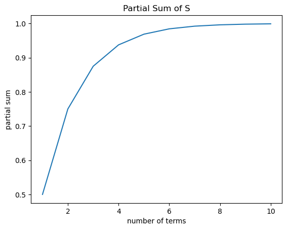

```python
n = np.linspace(1, 10, 10)
plt.title("Partial Sum of S")
plt.plot(n, S)
plt.xlabel("number of terms")
plt.ylabel("partial sum")
plt.show()
```

> As we add more terms, the partial sum gets closer and closer to 1!

### Exercise 6

The Fibonacci sequence starts with the numbers $0$ and $1$, and adds the two previous numbers in the sequence to get the next number. After $0, 1$, the next four numbers in the sequence would be $1, 2, 3, 5$ because $$\begin{aligned} 0 + 1 &= 1 \\ 1 + 1 &= 2 \\ 1 + 2 &= 3 \\ 2 + 3 &= 5. \end{aligned}$$

Print an array of the first 12 numbers in the Fibonacci sequence. You can learn more about the sequence here https://mathworld.wolfram.com/FibonacciNumber.html.

Hint: Exercise 1 g) may help you initialize the array.

(This is the same Exercise that was in "L02 Booleans and Loops" Exercise 6)

```python
# One possible solution
# Initialize an array where the first two entries are 0 and 1
f = np.zeros(12)
f[1] = 1

i = 2 # start by computing the third element of the array (index "2" in Python)
while i < 12:
    f[i] = f[i-1] + f[i-2] # Add the previous two numbers in the sequence
    i = i + 1

print(f)
```

```
[ 0.  1.  1.  2.  3.  5.  8. 13. 21. 34. 55. 89.]
```

```python
# A solution just starting with the first two numbers in the sequence
f = np.array([0, 1])

while len(f) < 12:
    next_number = f[-2] + f[-1] # add the last two numbers
    f = np.append(f, next_number)

print(f)
```

```
[ 0  1  1  2  3  5  8 13 21 34 55 89]
```

```python
# A clever solution without indexing
# Start with an empty array
f = np.array([])

# Define the starting numbers 0 and 1
a = 0
b = 1

while len(f) < 12:
    f = np.append(f, a) # add a to the array
    a_and_b = a + b # calculate the next term
    a = b # copy b into a
    b = a_and_b # copy a+b into b

print(f)
```

```
[ 0.  1.  1.  2.  3.  5.  8. 13. 21. 34. 55. 89.]
```